# Natural Language Processing in R - Assessment

Author

Jasper Cain

Published

December 2, 2025

## Introduction

The purpose of the assessment is to demonstrate what skills have been learned as part of an NLP using R course. The data-set is from a sample of newspaper articles from a British left-leaning newspaper, “The Guardian”, chosen because they mention key words related to Health and Social Care.

The exact methodology for choosing the sample of articles is not known.

This assessment will look to answer:

**What can different NLP analysis methods tell us about the priorities and writing styles of different journalists?**

## Pre-processing and understanding the data

**Click here to expand**

```r
library(tidyverse) # for tidy programming style
library(tidytext) # for unnesting tokens and other NLP functions
library(wordcloud2) # for wordclouds
library(textstem) # for stemma of words
library(udpipe) # for POS tagging
library(fmsb) # for radar charts
library(topicmodels) # for identify common topics
library(tm) # for creating document term matrices
```

```r
# only necessary if not already downloaded

if(length(list.files("guardian_data/"))==5){
  "files already downloaded" } else {
  dir.create("guardian_data")
 file_path_without_ending='https://raw.githubusercontent.com/drpawelo/data/refs/heads/main/health/nlp_guardian_batch_'
for (batch_id in 1:5) {
remote_file_name <- paste0(file_path_without_ending, batch_id, ".csv")
local_file_name <- paste0("guardian_data/guardian_articles_", batch_id, ".csv")}
if (!file.exists(local_file_name)){
      download.file(remote_file_name, local_file_name) }
 }
```

```r
# read the data into R

df_guardian_articles <- map(
  map(list.files("guardian_data/"),
    function(x){paste0("guardian_data/",x)}),
  read_csv) %>%
  list_rbind()
```

The data consists of 19,172 articles. The earliest was published the 01/01/2023 and the latest on 17/11/2024. This period covers several newsworthy events which would have an impact on Health, not least including the General Election, Resident Doctor and Nurse Strikes, and the Covid Inquiry.

Most articles come from the “news” category, although there is a good spread across all sections of the newspaper.

### Spread of Article Types

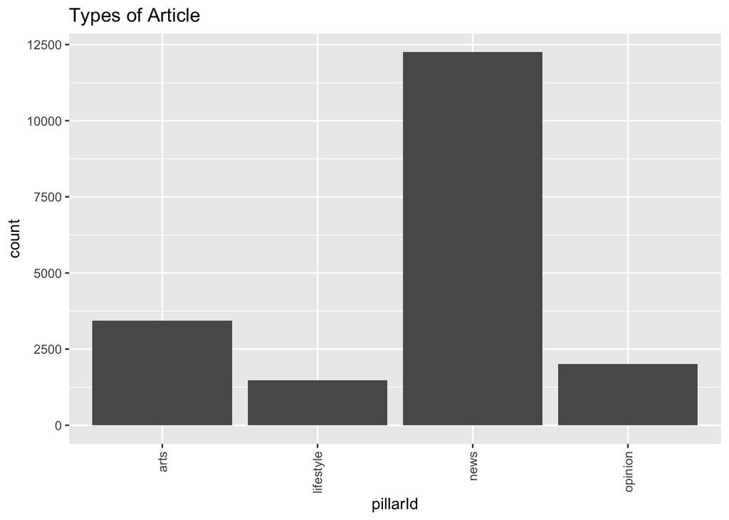

```r
ggplot(df_guardian_articles,
       aes(x=pillarId)) +
  geom_bar() +
  scale_x_discrete(guide = guide_axis(angle = 90)) +
  labs(title="Types of Article")
```

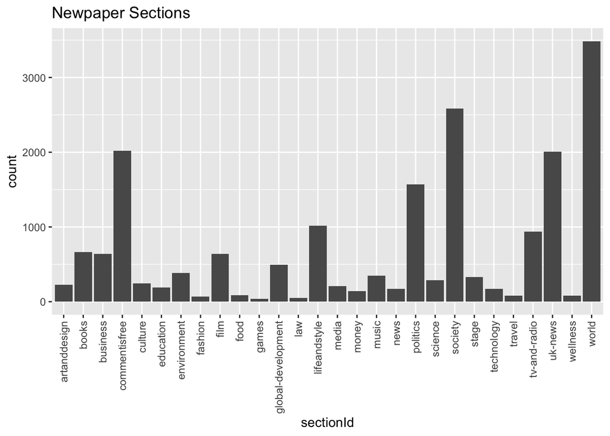

```r
ggplot(df_guardian_articles) +
  geom_bar(aes(x=sectionId)) +
  scale_x_discrete(guide = guide_axis(angle = 90)) +
  labs(title="Newpaper Sections")
```

### Authors

```r
 # articles by author
 author_articles <- df_guardian_articles %>%
   group_by(fields.byline) %>%
   summarise("number_of_articles"=n()) %>%
   arrange(desc(number_of_articles))
```

There are 5,378 unique bylines/authors attributed to this dataset.

A quick review of the data shows that articles with no byline appear to be comments from members of the public, not articles by guardian journalists.

They have been excluded to try and ensure that the data is more representative of the editorial output of the guardian newspaper itself.

In order to focus the analysis on large sample sizes, we will further limit our analysis to bylines with over 100 articles.

```r
author_articles %>% filter(number_of_articles>=100) %>%
  filter(!is.na(fields.byline))
```

```
# A tibble: 14 × 2
   fields.byline                       number_of_articles
   <chr>                                            <int>
 1 Denis Campbell Health policy editor                274
 2 Andrew Gregory Health editor                       253
 3 Andrew Sparrow                                     244
 4 Editorial                                          223
 5 Steven Morris                                      157
 6 Archie Bland                                       153
 7 Nadeem Badshah                                     137
 8 Nimo Omer                                          124
 9 John Crace                                         123
10 Graeme Wearden                                     114
11 Jamie Grierson                                     108
12 Guardian staff and agencies                        106
13 Nicola Davis Science correspondent                 106
14 Rachel Hall                                        102
```

Excluding the generic bylines “Editorial” and “Guardian staff and agencies” leaves 12 authors.

```r
df_articles_reduced <- df_guardian_articles %>%
  filter(fields.byline %in% unique(
    author_articles %>%
      filter(number_of_articles>=100) %>%
      filter(!is.na(fields.byline)) %>%
  filter(!fields.byline %in% c("","Editorial","Guardian staff and agencies")))$fields.byline)

df_articles_reduced %>%
  group_by(fields.byline) %>%
  summarise(number_of_articles=n())
```

```
# A tibble: 12 × 2
   fields.byline                       number_of_articles
   <chr>                                            <int>
 1 Andrew Gregory Health editor                       253
 2 Andrew Sparrow                                     244
 3 Archie Bland                                       153
 4 Denis Campbell Health policy editor                274
 5 Graeme Wearden                                     114
 6 Jamie Grierson                                     108
 7 John Crace                                         123
 8 Nadeem Badshah                                     137
 9 Nicola Davis Science correspondent                 106
10 Nimo Omer                                          124
11 Rachel Hall                                        102
12 Steven Morris                                      157
```

These authors cover a spread of the newpapers sections, although there is a higher proportion of articles within the politics, society, uk-news and world sections.

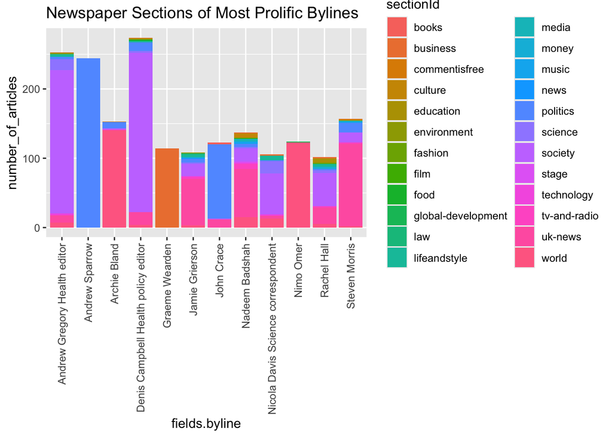

```r
df_articles_reduced %>%
  group_by(fields.byline,sectionId) %>%
  summarise(number_of_articles=n()) %>%
  ggplot(aes(x=fields.byline,
             y=number_of_articles,
             fill=sectionId)) +
  geom_col() +
  scale_x_discrete(guide = guide_axis(angle = 90)) +
  labs(title="Newspaper Sections of Most Prolific Bylines")
```

It is worth noting that this reduced cohort of authors produce almost entirely “news” output, instead of Opinions, Art or Lifestyle.

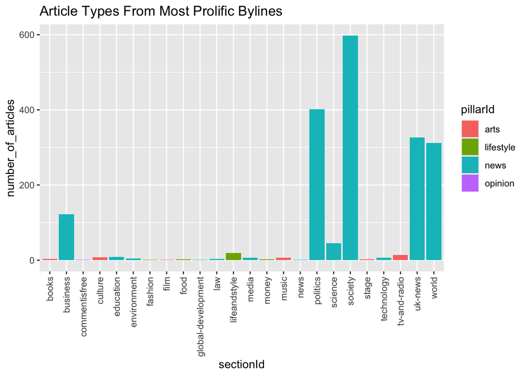

```r
df_articles_reduced %>%
  group_by(sectionId,pillarId) %>%
  summarise(number_of_articles=n()) %>%
  ggplot(aes(x=sectionId,
             y=number_of_articles,
             fill=pillarId)) +
  geom_col() +
  scale_x_discrete(guide = guide_axis(angle = 90)) +
  labs(title = "Article Types From Most Prolific Bylines")
```

## Writing Styles

### Sentence length

**Click to expand**

I wanted to understand the length of the average sentence for each author. This identified some variation.

However, not all words are created equal, so I wanted to remove standard stop words and leave only an approximation of the most meaningful words in each article.

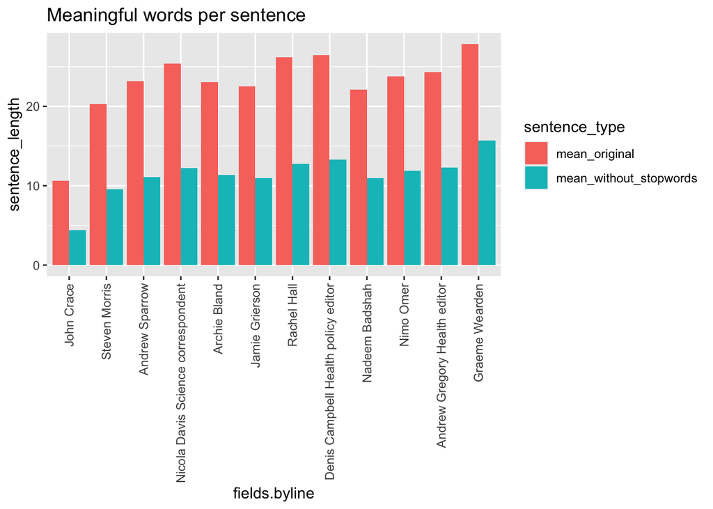

```r
f_removeWords <- function(str) {
  x <- unlist(strsplit(str, " "))
  paste(x[!x %in% unique(stop_words$word)], collapse = " ")
} #function to remove stop_words from each sentence


df_sentence_length <- df_articles_reduced %>%
  group_by(fields.byline) %>%
  unnest_tokens(input=fields.text,token = "sentences",output = sentence) %>%
  mutate(sentence_length = str_count(sentence, boundary("word"))) %>%
  summarise("mean_original" = mean(sentence_length)) %>%
  left_join(
 df_articles_reduced %>%
  group_by(fields.byline) %>%
  unnest_tokens(input=fields.text,token = "sentences",output = sentence) %>%
      mutate(sentence2=sapply(sentence,f_removeWords)) %>%
  mutate(sentence_length2 = str_count(sentence2, boundary("word"))) %>%
  summarise("mean_without_stopwords" = mean(sentence_length2))) %>%
  mutate(percentage_words_removed =round(1-(mean_without_stopwords/mean_original),2))
df_sentence_length %>%
  pivot_longer(cols = mean_original:mean_without_stopwords,
               values_to = "sentence_length",
               names_to = "sentence_type") %>%
  mutate(fields.byline = fct_reorder(fields.byline,desc(percentage_words_removed))) %>%
  ggplot() +
  geom_col(aes(x=fields.byline,
               y=sentence_length,
               fill=sentence_type),
               position=position_dodge()) +
  scale_x_discrete(guide = guide_axis(angle = 90)) +
  labs(title = "Meaningful words per sentence")
```

There is a difference between the number of stop-words used in articles by journalists. The biggest difference on a sentence-by-sentence basis are articles by John Crace. Removing stop-words from his articles reduced average words per sentence by 59%. Not bad when being paid by the word….

Graeme Wearden uses the least “filler” words. Only 44% of his sentences, on average, are stop-words.

This is obviously a very crude measure of the impact of writing, and stop-words are important for context and clarity. However, significant differences suggest that some authors could be more concise with their writing.

### Sentence Structures

**Click to expand**

I have analysed how each author uses language differently, particularly the balance between word types.

Further work could be done in this space to include research about how emotive or engaging different authors are based on their use of language and sentence structure. Research could also take place looking at whether an author changes how they write depending if it is a news, opinion, or lifestyle piece.

```r
# Only download model if not previously done, it is a large file.

if(!file.exists("language_model/english-ewt-ud-2.5-191206.udpipe")){

dir.create("language_model")

udpipe_download_model(language = "english-ewt",            model_dir = "language_model/")
} else {
    "model already downloaded"}
```

```
[1] "model already downloaded"
```

```r
language_model <- udpipe_load_model(file = "language_model/english-ewt-ud-2.5-191206.udpipe")


f_annotate_pos <- function(byline){
  byline_text <- df_articles_reduced %>%
  filter(fields.byline==byline) %>%
  select(fields.text) %>%
  str_squish()

    udpipe_annotate(language_model, x = byline_text) %>%
    as.data.frame() %>%
  mutate(fields.byline=byline)
}

#Warning, the following function takes significant time, and results in a dataframe of nearly 5 million rows. Consider if you need to adapt the inputs to match your processing power.

df_annotated_text <- list_rbind(map(unique(df_articles_reduced$fields.byline),f_annotate_pos))
```

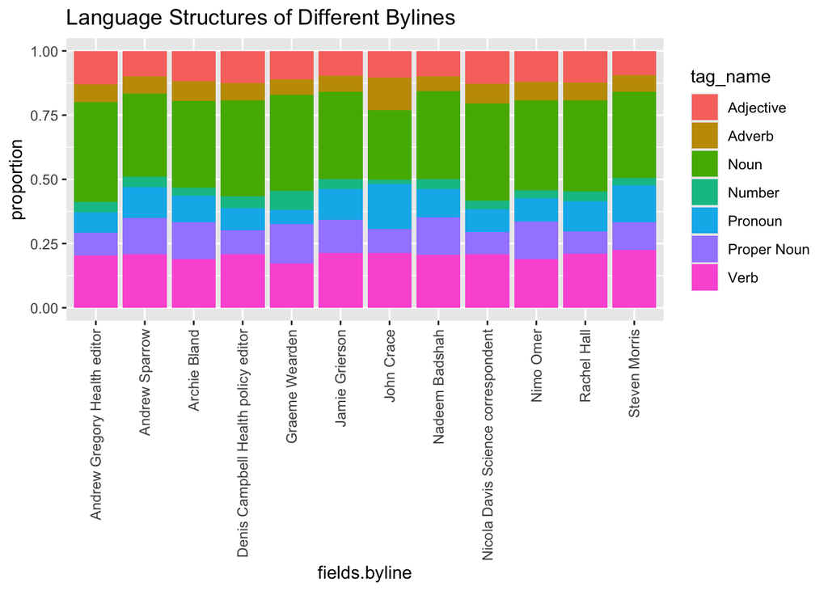

```r
df_reduced_annotated_text <- df_annotated_text %>%
  filter(upos %in% c("ADJ","ADV","NOUN","NUM","PRON","PROPN","VERB")) %>%
  mutate(tag_name = case_when(
    upos=="ADJ" ~ "Adjective",
    upos=="ADV" ~ "Adverb",
    upos=="NOUN" ~ "Noun",
    upos=="NUM" ~ "Number",
    upos=="PRON" ~ "Pronoun",
    upos=="PROPN" ~ "Proper Noun",
    upos=="VERB" ~ "Verb"
  ))

  df_reduced_annotated_text %>%
    group_by(fields.byline,tag_name) %>%
    summarise(count=n()) %>%
  left_join(df_reduced_annotated_text %>%
  group_by(fields.byline,) %>%
  summarise(total=n())) %>%
  mutate(proportion=count/total) %>%
  ggplot() +
  geom_col(aes(x=fields.byline,
               y=proportion,
               fill=tag_name)) +
  scale_x_discrete(guide = guide_axis(angle = 90)) +
  labs(title="Language Structures of Different Bylines")
```

## Author Topics

### Wordclouds

**Click to expand**

To identify common themes in articles, I started by using a wordcloud to visualise commonly used words.

Some initial issues which have meant more cleansing was needed included:

- Some (but not all) articles start with the time of publishing
- numbers are commonly used, but mean nothing in isolation

Other measures taken are:

- lemmatising words to make as consistent as possible
- removing stopwords to focus on most meaningful words
- reduce words to top 100 to focus on most obvious themes

```r
f_byline_word_freq <- function(byline){
 df_articles_reduced %>%
    filter(fields.byline==byline) %>%
    mutate(lemma_text=sapply(fields.text, lemmatize_strings)) %>%
    mutate(clean_text=
    str_remove_all(
    str_remove_all(
    str_remove_all(
    str_remove_all(
    str_remove_all(
        lemma_text,
      "(\\d+)"), #remove digits
      "GMT\\s+"), #remove greewich mean time
      "BST\\s+"), #remove british summer time
    "\\s+pm\\s+"), #remove pm (time)
    "\\s+am\\s+") #remove am (time)
    ) %>%
    unnest_tokens(output = word,input = clean_text) %>%
    anti_join(stop_words) %>%
    count(word,sort=TRUE) %>%
    rename(freq=n) %>%
    top_n(100)
}

f_wordclouds <- function(byline){
  f_byline_word_freq(byline) %>%
    wordcloud2()
}
```

**Graeme Wearden**

```r
f_wordclouds("Graeme Wearden")
```

[interactive chart not shown]

**Andrew Sparrow**

```r
f_wordclouds("Andrew Sparrow")
```

[interactive chart not shown]

**Denis Campbell Health policy editor**

```r
f_wordclouds("Denis Campbell Health policy editor")
```

[interactive chart not shown]

**Rachel Hall**

```r
f_wordclouds("Rachel Hall")
```

[interactive chart not shown]

**Archie Bland**

```r
f_wordclouds("Archie Bland")
```

[interactive chart not shown]

**Nadeem Badshah**

```r
f_wordclouds("Nadeem Badshah")
```

[interactive chart not shown]

**Nicola Davis Science correspondent**

```r
f_wordclouds("Nicola Davis Science correspondent")
```

[interactive chart not shown]

**Andrew Gregory Health editor**

```r
f_wordclouds("Andrew Gregory Health editor")
```

[interactive chart not shown]

**Nimo Omer**

```r
f_wordclouds("Nimo Omer")
```

[interactive chart not shown]

**Jamie Grierson**

```r
f_wordclouds("Jamie Grierson")
```

[interactive chart not shown]

**Steven Morris**

```r
f_wordclouds("Steven Morris")
```

[interactive chart not shown]

**John Crace**

```r
f_wordclouds("John Crace" )
```

[interactive chart not shown]

### ngrams

**Click to expand**

For a clearer analysis, I also undertook a basic frequency analysis of the top 5 words and bi-grams for each author, providing an easier format for comparison.

I did not cleanse the articles of anything except the vanilla stopwords for these charts.

#### Top 5 Words per Author

It is possible to intuit what types of journalists each author may be from these, although the “daily briefings” mask any insights from some journalists.

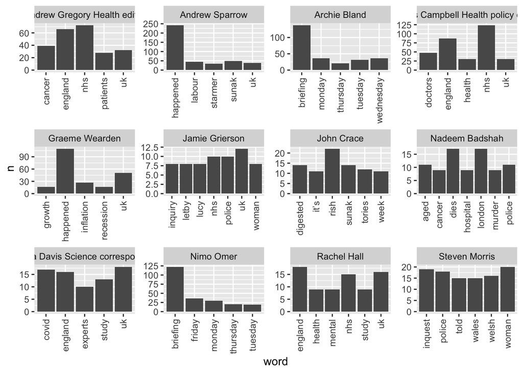

```r
df_articles_reduced %>%
  group_by(fields.byline) %>%
unnest_tokens(output = word,input = fields.headline) %>%
  anti_join(stop_words) %>%
  count(word,sort=TRUE) %>%
  top_n(5) %>%
  ggplot(aes(x=word,y=n)) +
  geom_bar(stat = "identity") +
  facet_wrap(~fields.byline, scales="free")+
  scale_x_discrete(guide = guide_axis(angle = 90)) -> word_freq_C
(word_freq_C)
```

#### Top 5 Bi-grams per Author

There are many more bi-grams which are of equal frequency compared to single words for each author. Like the word frequency analysis, it is clear to see what further cleansing would be needed to make this more useful - e.g. Friday Briefings.

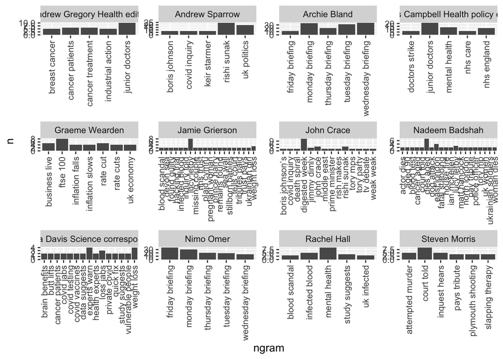

```r
df_articles_reduced %>%
  group_by(fields.byline) %>%
unnest_tokens(output = ngram,input = fields.headline, token = "ngrams",n=2) %>%
  separate(ngram, into = c("first","second"),
           sep = " ", remove = FALSE) %>%
  anti_join(stop_words,
            by = c("first" = "word")) %>%
  anti_join(stop_words,
            by = c("second" = "word")) %>%
  count(ngram,sort=TRUE) %>%
  top_n(5) %>%
  ggplot(aes(x=ngram,y=n)) +
  geom_bar(stat = "identity") +
  facet_wrap(~fields.byline, scales="free")+
  scale_x_discrete(guide = guide_axis(angle = 90)) -> bigram_freq_C
(bigram_freq_C)
```

### Topic Modelling

**Click to expand**

I also used the topicmodels package to pull out the top topic terms for each journalist, to give a move rounded idea of the priorities for each author. This would be interesting to peruse further, particularly triangulating with the newspaper sections these journalists most commonly write for.

```r
f_word_removal <- function(byline){
  removal_patterns<-"(\\d+)|(\\sam\\s)|(\\spm\\s)|(gmt)\\s|(bst)\\s|(afternoon)|(evening)|(early evening)|(summary)|(the\\s)|(says\\s)|(will\\s)|(\\sits\\s)|(said)|(can\\s)|(was\\s)|(not\\s)|(have\\s)|(this\\s)|(their\\s)|(they\\s)|(been\\s)|(are\\s)|(that\\s)|(also\\s)|(had\\s)|(were\\s)|(she\\s)|(her\\s)|(\\sis\\s)|(\\shis\\s)|(\\shas\\s)|"
removal_patterns <- paste0(removal_patterns,str_flatten(tm::stopwords("en"),collapse = "\\s|\\s"))

return(df_articles_reduced %>%
  filter(fields.byline==byline) %>%
    mutate(
  fields.text.clean =
    str_replace_all(
      str_remove_all(
        str_to_lower(fields.text),
        "[[:punct:]]"),
      removal_patterns,
      replacement = " ") %>%
  str_replace_all("\\s+"," ")))
}

f_byline_corpus<- function(byline){
  Corpus(
    VectorSource(
      f_word_removal(byline)$fields.text.clean))
}

f_byline_dtm <- function(byline){
  DocumentTermMatrix(
    f_byline_corpus(byline))
}


f_topic_model <- function(byline){
  byline_LDA <- LDA(f_byline_dtm(byline),
                k=3,
                control=list(seed=1234))
  terms(byline_LDA,10)
}
```

**Graeme Wearden**

```r
f_topic_model("Graeme Wearden")
```

```
      Topic 1     Topic 2     Topic 3
 [1,] "inflation" "year"      "growth"
 [2,] "year"      "related"   "economy"
 [3,] "rate"      "last"      "gdp"
 [4,] "rates"     "its"       "year"
 [5,] "growth"    "bank"      "energy"
 [6,] "interest"  "sales"     "related"
 [7,] "bank"      "new"       "government"
 [8,] "economy"   "market"    "new"
 [9,] "last"      "inflation" "investment"
[10,] "market"    "prices"    "tax"
```

**Andrew Sparrow**

```r
f_topic_model("Andrew Sparrow")
```

```
      Topic 1      Topic 2      Topic 3
 [1,] "labour"     "sunak"      "government"
 [2,] "starmer"    "government" "sunak"
 [3,] "government" "people"     "updated"
 [4,] "people"     "updated"    "people"
 [5,] "party"      "labour"     "labour"
 [6,] "election"   "his"        "minister"
 [7,] "now"        "inquiry"    "secretary"
 [8,] "his"        "minister"   "starmer"
 [9,] "see"        "rish"       "pay"
[10,] "minister"   "party"      "see"
```

**Denis Campbell Health policy editor**

```r
f_topic_model("Denis Campbell Health policy editor")
```

```
      Topic 1     Topic 2    Topic 3
 [1,] "nhs"       "nhs"      "health"
 [2,] "health"    "doctors"  "people"
 [3,] "patients"  "pay"      "cancer"
 [4,] "people"    "health"   "food"
 [5,] "mental"    "staff"    "government"
 [6,] "england"   "junior"   "nhs"
 [7,] "services"  "strike"   "research"
 [8,] "staff"     "england"  "obesity"
 [9,] "hospital"  "patients" "year"
[10,] "hospitals" "nurses"   "risk"
```

**Rachel Hall**

```r
f_topic_model("Rachel Hall")
```

```
      Topic 1      Topic 2      Topic 3
 [1,] "year"       "health"     "people"
 [2,] "people"     "people"     "health"
 [3,] "nhs"        "nhs"        "cancer"
 [4,] "strike"     "mental"     "mental"
 [5,] "england"    "research"   "women"
 [6,] "students"   "services"   "one"
 [7,] "gcse"       "patients"   "police"
 [8,] "school"     "government" "and"
 [9,] "government" "one"        "years"
[10,] "results"    "years"      "support"
```

**Archie Bland**

```r
f_topic_model("Archie Bland")
```

```
      Topic 1  Topic 2  Topic 3
 [1,] "people" "people" "people"
 [2,] "his"    "his"    "his"
 [3,] "new"    "one"    "one"
 [4,] "labour" "new"    "last"
 [5,] "one"    "last"   "new"
 [6,] "last"   "day"    "government"
 [7,] "like"   "years"  "has"
 [8,] "day"    "israel" "its"
 [9,] "its"    "year"   "first"
[10,] "now"    "has"    "now"
```

**Nadeem Badshah**

```r
f_topic_model("Nadeem Badshah")
```

```
      Topic 1    Topic 2  Topic 3
 [1,] "police"   "his"    "nhs"
 [2,] "family"   "family" "people"
 [3,] "incident" "people" "his"
 [4,] "hospital" "two"    "health"
 [5,] "bbc"      "one"    "hospital"
 [6,] "his"      "israel" "told"
 [7,] "two"      "show"   "cancer"
 [8,] "man"      "last"   "year"
 [9,] "officers" "told"   "and"
[10,] "yearold"  "actor"  "time"
```

**Nicola Davis Science correspondent**

```r
f_topic_model("Nicola Davis Science correspondent")
```

```
      Topic 1    Topic 2      Topic 3
 [1,] "covid"    "people"     "people"
 [2,] "people"   "research"   "weight"
 [3,] "health"   "dementia"   "health"
 [4,] "nhs"      "women"      "patients"
 [5,] "children" "found"      "drugs"
 [6,] "vaccine"  "brain"      "risk"
 [7,] "measles"  "study"      "obesity"
 [8,] "ukhsa"    "alzheimers" "nhs"
 [9,] "years"    "disease"    "cancer"
[10,] "england"  "health"     "blood"
```

**Andrew Gregory Health editor**

```r
f_topic_model("Andrew Gregory Health editor")
```

```
      Topic 1       Topic 2     Topic 3
 [1,] "health"      "cancer"    "nhs"
 [2,] "people"      "patients"  "patients"
 [3,] "children"    "people"    "health"
 [4,] "risk"        "treatment" "doctors"
 [5,] "study"       "research"  "england"
 [6,] "mental"      "disease"   "action"
 [7,] "diabetes"    "risk"      "staff"
 [8,] "one"         "nhs"       "government"
 [9,] "found"       "new"       "people"
[10,] "researchers" "women"     "hospital"
```

**Nimo Omer**

```r
f_topic_model("Nimo Omer")
```

```
      Topic 1      Topic 2      Topic 3
 [1,] "people"     "government" "people"
 [2,] "has"        "new"        "israel"
 [3,] "new"        "people"     "his"
 [4,] "one"        "one"        "new"
 [5,] "years"      "years"      "government"
 [6,] "his"        "his"        "one"
 [7,] "government" "has"        "has"
 [8,] "first"      "now"        "its"
 [9,] "time"       "first"      "day"
[10,] "day"        "all"        "years"
```

**Jamie Grierson**

```r
f_topic_model("Jamie Grierson")
```

```
      Topic 1       Topic 2    Topic 3
 [1,] "harry"       "police"   "hospital"
 [2,] "green"       "his"      "nhs"
 [3,] "court"       "people"   "two"
 [4,] "his"         "told"     "people"
 [5,] "mirror"      "baby"     "police"
 [6,] "article"     "hospital" "health"
 [7,] "information" "found"    "told"
 [8,] "prince"      "one"      "inquiry"
 [9,] "sherborne"   "and"      "three"
[10,] "phone"       "time"     "letby"
```

**Steven Morris**

```r
f_topic_model("Steven Morris")
```

```
      Topic 1      Topic 2  Topic 3
 [1,] "wales"      "police" "his"
 [2,] "welsh"      "told"   "police"
 [3,] "people"     "his"    "inquest"
 [4,] "government" "and"    "told"
 [5,] "labour"     "family" "family"
 [6,] "police"     "one"    "hospital"
 [7,] "first"      "court"  "death"
 [8,] "minister"   "school" "one"
 [9,] "one"        "people" "and"
[10,] "mph"        "woman"  "people"
```

**John Crace**

```r
f_topic_model("John Crace" )
```

```
      Topic 1  Topic 2 Topic 3
 [1,] "just"   "just"  "just"
 [2,] "one"    "one"   "one"
 [3,] "sunak"  "his"   "his"
 [4,] "his"    "sunak" "rish"
 [5,] "time"   "all"   "even"
 [6,] "all"    "now"   "sunak"
 [7,] "people" "time"  "people"
 [8,] "even"   "rish"  "all"
 [9,] "rish"   "even"  "time"
[10,] "would"  "like"  "going"
```

## Author Sentiments

**Click to expand**

Finally, I looked into how positive or negative a skew was being written into the articles.

To do this, I compared how many negative sentiment words and positive sentiment words were used across the entire corpus of each journalist.

The results show that Andrew Sparrow is the most cheerful journalist, whilst Jamie Grierson seems a bit down.

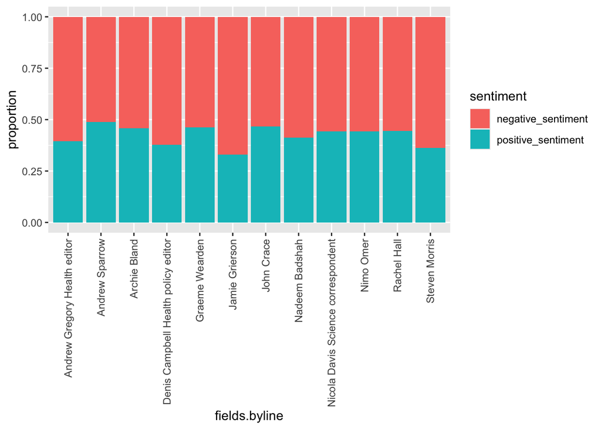

```r
df_articles_reduced %>% unnest_tokens(output = word,input = fields.text) %>%
 inner_join(get_sentiments("bing")) %>%
 group_by(fields.byline,sentiment) %>%
  summarise(count_sentiments=n()) %>%
  pivot_wider(names_from = sentiment,
              values_from = count_sentiments) %>%
  mutate(positive_sentiment=positive/(positive+negative),
        negative_sentiment=negative/(positive+negative)) %>%
  select(fields.byline,positive_sentiment,negative_sentiment) %>%
  pivot_longer(cols = !fields.byline,
               names_to = "sentiment",
               values_to = "proportion") %>% ggplot() +
  geom_col(aes(x=fields.byline,
               y=proportion,
               fill=sentiment)) +
  # geom_col(aes(x=fields.byline,
  #              y=count_sentiments,
  #              fill=sentiment)) +
  scale_x_discrete(guide = guide_axis(angle = 90))
```